# Analysis of Health Survey Data and Supplement Use

Hisham A. Harmali

2025-04-21

## 1. Introduction

This report presents a statistical analysis conducted as part of a graduation research project focused on understanding health behaviors. The primary objective was to explore factors potentially associated with dietary supplement use among the surveyed participants, using the cleaned dataset data_c. Key variables examined included demographics (age, gender, education, income), health indicators (BMI), and lifestyle choices (smoking status). All data preparation, analysis, and visualization were performed using the R programming language and associated packages (primarily the tidyverse). The data analysis component of this team-based research project was conducted solely by Hisham A. Harmali. This document serves as a showcase of these analytical steps and findings.

## 2. Data Loading and Preparation

The analysis uses the pre-cleaned dataset from an Excel file. Key preparation steps performed within this document include renaming columns, converting `Income` to numeric, and setting categorical variables as factors.

In accordance with ethical guidelines and to protect participant privacy, the underlying dataset (data_c) is not included in this public repository. Please refer to the Data Description section for details on the variables analyzed.

### 2.1 Load Data

```r
# Load the CLEANED data file from its saved location
# data_c.xlsx is in a 'data' subfolder: "data/data_c.xlsx"

data_c_raw <- read_excel("data/data_c.xlsx") # Load into a temporary raw object first

# Basic check after loading
if (is.null(data_c_raw)) {
   stop("Error: Failed to load data_c from the specified Excel file. Check the path.")
} else {
  print("Raw data loaded successfully from Excel.")
}
```

```
## [1] "Raw data loaded successfully from Excel."
```

### 2.2 Rename Columns

The original column names contained spaces, special characters, and colons. They are renamed here for easier use in R code.

```r
# Rename columns (using the structure identified previously)
data_c <- data_c_raw %>% # Start with the raw loaded data
  rename(
    # New Name = `Old Name (exactly as in original file)`
    # --- Names WITH colon ---
    Age                = `Age:`,
    Gender             = `Gender:`,
    Weight_kg          = `Weight(kg):`,
    Height_cm          = `Height(cm):`,
    BMI                = `BMI:`,
    BMICategory_orig   = `Category of BMI:`,
    Education_level    = `Education level:`,
    Income             = `Income:`,
    Smoking_Status     = `Smoking:`,
    Gym_Reason         = `The reason for going to the gym:`,
    Gym_Time           = `Time at the gym (per day):`,
    Exercise_Type      = `Type of exercise:`,
    Injury_Reasons_POV = `From your point of view, what are the reasons of injury at the gym:`,
    Gym_Injury_History = `Have you ever experienced injury or pain in the gym:`,

    # --- Names WITHOUT colon ---
    Supplement_Use     = `Are you currently using any supplements?`,
    Supplement_Duration = `How long have supplements been used?`,
    Supplement_InfoSource = `What are your sources of information about supplements?`,
    Supplement_Types_Taken = `What supplements do you specifically take?`,
    Supplement_Reason  = `What is the main reason for using supplements?`,
    Supplement_Frequency = `How often do you take supplements?`,
    Supplement_InfluenceFactors = `What factors influence your decision to buy supplements?`,
    Supplement_PurchasePlace = `Where do you prefer to buy supplements?`,
    Supplement_MotivationNew = `What motivates you to try a new supplement?`
  )

# Check the new names
print("Cleaned column names:")
```

```
## [1] "Cleaned column names:"
```

```r
print(colnames(data_c))
```

```
##  [1] "Age"                         "Gender"
##  [3] "Weight_kg"                   "Height_cm"
##  [5] "BMI"                         "BMICategory_orig"
##  [7] "Education_level"             "Income"
##  [9] "Smoking_Status"              "Gym_Reason"
## [11] "Gym_Time"                    "Exercise_Type"
## [13] "Injury_Reasons_POV"          "Gym_Injury_History"
## [15] "Supplement_Use"              "Supplement_Duration"
## [17] "Supplement_InfoSource"       "Supplement_Types_Taken"
## [19] "Supplement_Reason"           "Supplement_Frequency"
## [21] "Supplement_InfluenceFactors" "Supplement_PurchasePlace"
## [23] "Supplement_MotivationNew"
```

### 2.3 Convert Data Types

Convert `Income` to numeric and key categorical variables to factors. Create `GoesToGym` variable.

```r
# Convert data types
data_c <- data_c %>%
  mutate(
    # Convert Income to numeric
    Income = parse_number(as.character(Income)),

    # Create GoesToGym variable based on Gym_Reason
    GoesToGym = factor(ifelse(!is.na(Gym_Reason) & Gym_Reason != "", "Yes", "No")),

    # Convert key categorical variables to factors
    Gender = as.factor(Gender),
    Education_level = as.factor(Education_level),
    Smoking_Status = as.factor(Smoking_Status),
    Supplement_Use = as.factor(Supplement_Use), # Ensure levels are No, Yes etc.
    BMICategory_orig = as.factor(BMICategory_orig)
    # Add any other factor conversions if needed
  )

# Verify the final structure
print("Final structure of prepared data_c:")
```

```
## [1] "Final structure of prepared data_c:"
```

```r
str(data_c)
```

```
## tibble [321 × 24] (S3: tbl_df/tbl/data.frame)
##  $ Age                        : num [1:321] 30 52 37 45 40 27 38 38 40 33 ...
##  $ Gender                     : Factor w/ 2 levels "Female","Male": 2 1 1 1 2 2 2 2 1 2 ...
##  $ Weight_kg                  : num [1:321] 88 58 65 75 88 67 85 70 64 77 ...
##  $ Height_cm                  : num [1:321] 176 150 155 150 170 162 169 166 158 174 ...
##  $ BMI                        : num [1:321] 28.4 25.8 27.1 33.3 30.4 25.5 29.8 25.4 25.6 25.4 ...
##  $ BMICategory_orig           : Factor w/ 4 levels "Normal","Obese",..: 3 3 3 2 2 3 3 3 3 3 ...
##  $ Education_level            : Factor w/ 5 levels "Bachelor","Diploma",..: 1 1 1 1 1 1 1 1 1 3 ...
##  $ Income                     : num [1:321] 20000 19800 18700 18000 18000 18000 17000 17000 16000 16000 ...
##  $ Smoking_Status             : Factor w/ 2 levels "No","Yes": 1 1 1 1 1 1 1 1 1 1 ...
##  $ Gym_Reason                 : chr [1:321] "Improve fitness" "Improve fitness" "Improve fitness" "Entertainment (waste time)" ...
##  $ Gym_Time                   : chr [1:321] "One Hour" "Two hours" "One Hour" "One Hour" ...
##  $ Exercise_Type              : chr [1:321] "Resistance exercises" "Resistance exercises" "Resistance exercises" "Resistance exercises" ...
##  $ Injury_Reasons_POV         : chr [1:321] "Wrong posture (technique is wrong), Lifting too heavy weight, Lack of knowledge of exercise, Insufficient infor"| __truncated__ "Excessive exercise" "Excessive exercise" "Lack of knowledge of exercise" ...
##  $ Gym_Injury_History         : chr [1:321] "Wrist/Hand, Back, Ankle/Foot, Shoulder" "Back" "Knee" "Knee" ...
##  $ Supplement_Use             : Factor w/ 2 levels "No","Yes": 2 1 2 2 1 2 2 2 2 1 ...
##  $ Supplement_Duration        : chr [1:321] "More than a year" "I don't use it at all" "6 months or less" "6 months or less" ...
##  $ Supplement_InfoSource      : chr [1:321] "Dietitian" "Dietitian" "Doctors" "Friends or family" ...
##  $ Supplement_Types_Taken     : chr [1:321] "Caffeine" "I don't use it at all" "Magnesium, Glutamine, • Zinc, • Vitamin D, • Vitamin C, • Vitamin B6, • Vitamin B12, • Iron" "Vitamin D" ...
##  $ Supplement_Reason          : chr [1:321] "Muscle recovery" "I don't use it at all" "Maintaining health" "Maintaining health" ...
##  $ Supplement_Frequency       : chr [1:321] "Daily" "I don't use it at all" "Weekly" "Weekly" ...
##  $ Supplement_InfluenceFactors: chr [1:321] "Price" "I don't use it at all" "Doctor's recommendations" "Product availability" ...
##  $ Supplement_PurchasePlace   : chr [1:321] "Health Stores" "I don't use it at all" "Pharmacies" "Pharmacies" ...
##  $ Supplement_MotivationNew   : chr [1:321] "Discounts And Deals, Advice from a health professional" "Recommendations from friends or family" "Advice from a health professional" "Advice from a health professional" ...
##  $ GoesToGym                  : Factor w/ 1 level "Yes": 1 1 1 1 1 1 1 1 1 1 ...
```

```r
# Check the levels created for GoesToGym (Expected: Only "Yes")
print("Check levels for GoesToGym:")
```

```
## [1] "Check levels for GoesToGym:"
```

```r
print(table(data_c$GoesToGym))
```

```
##
## Yes
## 321
```

The data_c dataframe is now prepared with clean names and appropriate data types. Income is numeric, and key categorical variables are factors. The GoesToGym variable confirmed all participants provided a gym reason and will be excluded from regression modeling.

## 3. Descriptive Statistics

Summarizing the key characteristics of the sample (N=321).

### 3.1 Numeric Variables

```r
# Calculate numeric summaries
numeric_summary <- data_c %>%
  summarise(across(c(Age, Weight_kg, Height_cm, BMI, Income),
                   list(
                     N = ~sum(!is.na(.x)),
                     Mean = ~mean(.x, na.rm = TRUE),
                     Median = ~median(.x, na.rm = TRUE),
                     SD = ~sd(.x, na.rm = TRUE),
                     Min = ~min(.x, na.rm = TRUE),
                     Max = ~max(.x, na.rm = TRUE)
                   ),
                   .names = "{.col}_{.fn}"))

# Display the table
print("Numeric Variable Summaries:")
```

```
## [1] "Numeric Variable Summaries:"
```

```r
# knitr::kable(numeric_summary, caption = "Summary Statistics for Numeric Variables", digits = 1) # Nicer table option
print(numeric_summary)
```

```
## # A tibble: 1 × 30
##   Age_N Age_Mean Age_Median Age_SD Age_Min Age_Max Weight_kg_N Weight_kg_Mean
##   <int>    <dbl>      <dbl>  <dbl>   <dbl>   <dbl>       <int>          <dbl>
## 1   321     27.4         25   7.77      18      52         321           68.7
## # ℹ 22 more variables: Weight_kg_Median <dbl>, Weight_kg_SD <dbl>,
## #   Weight_kg_Min <dbl>, Weight_kg_Max <dbl>, Height_cm_N <int>,
## #   Height_cm_Mean <dbl>, Height_cm_Median <dbl>, Height_cm_SD <dbl>,
## #   Height_cm_Min <dbl>, Height_cm_Max <dbl>, BMI_N <int>, BMI_Mean <dbl>,
## #   BMI_Median <dbl>, BMI_SD <dbl>, BMI_Min <dbl>, BMI_Max <dbl>,
## #   Income_N <int>, Income_Mean <dbl>, Income_Median <dbl>, Income_SD <dbl>,
## #   Income_Min <dbl>, Income_Max <dbl>
```

The analysis included 321 participants. The average age was 27.4 years (SD = 7.77), with a median of 25 years and ages ranging from 18 to 52. On average, participants weighed 68.7 kg (SD = 16.30; Median = 67.0; Range = 26-139) and had a height of 166.9 cm (SD = 8.57; Median = 169; Range = 143-198). The mean Body Mass Index (BMI) was 24.6 (SD = 5.13; Median = 24.0), falling near the upper end of the ‘Normal’ weight category on average, although individual values ranged widely from 10.2 to 47.0. The reported income, treated as numeric, had a mean of approximately 4993 SAR (SD = 4899) but a median of only 3000 SAR (Range = 0-20000), suggesting a right-skewed distribution with considerable variation.

### 3.2 Categorical Variables

```r
# Run summaries for categorical variables
print("Categorical Variable Summaries:")
```

```
## [1] "Categorical Variable Summaries:"
```

```r
summarize_categorical(data_c, "Gender")
```

```
## [1] "Summary for: Gender"
## # A tibble: 2 × 3
##   Gender Count Percentage
##   <fct>  <int>      <dbl>
## 1 Female    76       23.7
## 2 Male     245       76.3
```

```r
summarize_categorical(data_c, "Education_level")
```

```
## [1] "Summary for: Education_level"
## # A tibble: 5 × 3
##   Education_level Count Percentage
##   <fct>           <int>      <dbl>
## 1 Bachelor          166       51.7
## 2 Diploma            71       22.1
## 3 High School        82       25.5
## 4 Master              1        0.3
## 5 Middle School       1        0.3
```

```r
summarize_categorical(data_c, "Smoking_Status")
```

```
## [1] "Summary for: Smoking_Status"
## # A tibble: 2 × 3
##   Smoking_Status Count Percentage
##   <fct>          <int>      <dbl>
## 1 No               282       87.9
## 2 Yes               39       12.1
```

```r
summarize_categorical(data_c, "Supplement_Use")
```

```
## [1] "Summary for: Supplement_Use"
## # A tibble: 2 × 3
##   Supplement_Use Count Percentage
##   <fct>          <int>      <dbl>
## 1 No               142       44.2
## 2 Yes              179       55.8
```

```r
summarize_categorical(data_c, "BMICategory_orig")
```

```
## [1] "Summary for: BMICategory_orig"
## # A tibble: 4 × 3
##   BMICategory_orig Count Percentage
##   <fct>            <int>      <dbl>
## 1 Normal             163       50.8
## 2 Obese               42       13.1
## 3 Overweight          83       25.9
## 4 Underweight         33       10.3
```

Summaries for key categorical variables revealed the sample composition. The participants were predominantly Male (76.3%). The most common education level was a Bachelor’s degree (51.7%), followed by High School (25.5%) and Diploma (22.1%); Master’s and Middle School levels were rare in this sample (N=1 each). A large majority of participants reported being non-smokers (87.9%). Regarding the primary outcome variable, slightly more participants reported using supplements (55.8%) than not (44.2%). Based on the original BMI categorization provided in the data, about half the sample was classified as ‘Normal’ weight (50.8%), with ‘Overweight’ (25.9%) being the next largest group.

## 4. Bivariate Analysis: Exploring Relationships

Testing for statistically significant relationships between pairs of variables (alpha = 0.05).

### 4.1 Categorical Associations (Chi-Square)

```r
# Gender vs. Supplement Use
print("Test: Gender vs Supplement Use")
```

```
## [1] "Test: Gender vs Supplement Use"
```

```r
chisq_gender_supp <- chisq.test(table(data_c$Gender, data_c$Supplement_Use))
print(chisq_gender_supp)
```

```
##
##  Pearson's Chi-squared test with Yates' continuity correction
##
## data:  table(data_c$Gender, data_c$Supplement_Use)
## X-squared = 1.1862, df = 1, p-value = 0.2761
```

```r
cat("\n")
```

```r
# Smoking Status vs. Supplement Use
print("Test: Smoking Status vs Supplement Use")
```

```
## [1] "Test: Smoking Status vs Supplement Use"
```

```r
chisq_smoke_supp <- chisq.test(table(data_c$Smoking_Status, data_c$Supplement_Use))
print(chisq_smoke_supp)
```

```
##
##  Pearson's Chi-squared test with Yates' continuity correction
##
## data:  table(data_c$Smoking_Status, data_c$Supplement_Use)
## X-squared = 0.0072575, df = 1, p-value = 0.9321
```

```r
cat("\n")
```

Based on the Chi-square test results that will be printed above there is no statistically significant association was found between Gender and Supplement Use (p = 0.276). Similarly, there was no significant association found between Smoking Status and Supplement Use (p = 0.932).

### 4.2 Mean BMI Comparisons (T-test & ANOVA)

```r
# BMI vs Supplement Use
print("Test: BMI by Supplement Use (T-test)")
```

```
## [1] "Test: BMI by Supplement Use (T-test)"
```

```r
t_test_bmi_supp <- t.test(BMI ~ Supplement_Use, data = data_c)
print(t_test_bmi_supp)
```

```
##
##  Welch Two Sample t-test
##
## data:  BMI by Supplement_Use
## t = 2.0611, df = 274.63, p-value = 0.04023
## alternative hypothesis: true difference in means between group No and group Yes is not equal to 0
## 95 percent confidence interval:
##  0.05406266 2.35553684
## sample estimates:
##  mean in group No mean in group Yes
##          25.23944          24.03464
```

```r
cat("\n")
```

The Welch Two Sample t-test indicated a statistically significant difference in mean BMI between supplement users (M ≈ 24.0) and non-users (M ≈ 25.2) (t(274.6) ≈ 2.06, p = 0.040). Participants who did not use supplements had a significantly higher average BMI than those who did in this sample.

```r
# BMI vs Education Level
print("Test: BMI by Education Level (ANOVA)")
```

```
## [1] "Test: BMI by Education Level (ANOVA)"
```

```r
anova_bmi_edu <- aov(BMI ~ Education_level, data = data_c)
print(summary(anova_bmi_edu))
```

```
##                  Df Sum Sq Mean Sq F value Pr(>F)
## Education_level   4     95   23.67     0.9  0.464
## Residuals       316   8311   26.30
```

```r
cat("\n")
```

```r
# Note: Post-hoc test not needed if overall ANOVA is not significant
```

The ANOVA test showed no statistically significant difference in mean BMI across the different education levels (F(4, 316) = 0.90, p = 0.464). Therefore, post-hoc tests comparing specific groups were not performed. Note should be taken of the very small sample sizes (N=1) for the Master’s and Middle School categories when considering this result.

### 4.3 Numeric Correlation (BMI vs Income)

```r
# BMI vs Income
print("Test: BMI vs Income (Correlation)")
```

```
## [1] "Test: BMI vs Income (Correlation)"
```

```r
cor_test_bmi_income <- cor.test(~ BMI + Income, data = data_c, use = "complete.obs")
print(cor_test_bmi_income)
```

```
##
##  Pearson's product-moment correlation
##
## data:  BMI and Income
## t = 4.4103, df = 319, p-value = 1.413e-05
## alternative hypothesis: true correlation is not equal to 0
## 95 percent confidence interval:
##  0.1337693 0.3402671
## sample estimates:
##       cor
## 0.2397277
```

```r
cat("\n")
```

A Pearson correlation test was conducted to examine the linear relationship between BMI and Income (both treated as numeric). The results showed a statistically significant, weak positive correlation between the two variables (r = 0.24, p < 0.001). This suggests that as income increases, BMI tends to increase slightly as well within this sample, although the relationship is not very strong.

## 5. Predictive Modeling: Logistic Regression

Building a model to predict Supplement Use based on multiple factors simultaneously. `GoesToGym` was excluded due to lack of variation.

```r
# Build the logistic regression model
# Ensure factor levels are appropriate, e.g., Supplement_Use is No then Yes
# levels(data_c$Supplement_Use) # Check levels if needed
# data_c$Supplement_Use <- factor(data_c$Supplement_Use, levels = c("No", "Yes")) # Relevel if needed BEFORE glm

logistic_model <- glm(Supplement_Use ~ Age + Gender + BMI + Income + Education_level + Smoking_Status,
                      data = data_c,
                      family = binomial(link = "logit"))

# View the model summary
print("Logistic Regression Model Summary:")
```

```
## [1] "Logistic Regression Model Summary:"
```

```r
# Consider using broom::tidy() and kable() for a publication-ready table
# print(knitr::kable(broom::tidy(logistic_model), digits = 3))
summary(logistic_model) # Base R output
```

```
##
## Call:
## glm(formula = Supplement_Use ~ Age + Gender + BMI + Income +
##     Education_level + Smoking_Status, family = binomial(link = "logit"),
##     data = data_c)
##
## Coefficients:
##                                Estimate Std. Error z value Pr(>|z|)
## (Intercept)                   1.293e+00  7.250e-01   1.783   0.0746 .
## Age                           1.139e-02  1.965e-02   0.580   0.5622
## GenderMale                   -1.876e-01  2.996e-01  -0.626   0.5312
## BMI                          -5.925e-02  2.461e-02  -2.408   0.0161 *
## Income                        3.911e-05  2.911e-05   1.343   0.1791
## Education_levelDiploma        1.847e-01  2.964e-01   0.623   0.5333
## Education_levelHigh School    1.615e-03  2.844e-01   0.006   0.9955
## Education_levelMaster        -1.514e+01  8.827e+02  -0.017   0.9863
## Education_levelMiddle School  1.433e+01  8.827e+02   0.016   0.9871
## Smoking_StatusYes            -1.722e-02  3.588e-01  -0.048   0.9617
## ---
## Signif. codes:  0 '***' 0.001 '**' 0.01 '*' 0.05 '.' 0.1 ' ' 1
##
## (Dispersion parameter for binomial family taken to be 1)
##
##     Null deviance: 440.73  on 320  degrees of freedom
## Residual deviance: 427.98  on 311  degrees of freedom
## AIC: 447.98
##
## Number of Fisher Scoring iterations: 13
```

```r
# Calculate Odds Ratios
print("Odds Ratios:")
```

```
## [1] "Odds Ratios:"
```

```r
# print(knitr::kable(data.frame(OR = exp(coef(logistic_model))), digits = 3))
print(exp(coef(logistic_model)))
```

```
##                  (Intercept)                          Age
##                 3.642453e+00                 1.011451e+00
##                   GenderMale                          BMI
##                 8.289423e-01                 9.424665e-01
##                       Income       Education_levelDiploma
##                 1.000039e+00                 1.202813e+00
##   Education_levelHigh School        Education_levelMaster
##                 1.001617e+00                 2.650738e-07
## Education_levelMiddle School            Smoking_StatusYes
##                 1.667125e+06                 9.829236e-01
```

```r
# Optional: Confidence Intervals for Odds Ratios
# print("Odds Ratios 95% Confidence Intervals:")
# print(knitr::kable(exp(confint(logistic_model)), digits = 3)) # Requires MASS package potentially
# print(exp(confint(logistic_model))) # Calculation can be slow & give warnings
```

A binary logistic regression model was fitted to predict the likelihood of Supplement Use based on age, gender, BMI, income, education level, and smoking status. The model summary indicated that, after controlling for other variables, only **BMI** was a statistically significant predictor (p = 0.016). The Odds Ratio (OR) for BMI was approximately 0.94 (95% CI [0.90, 0.99]), suggesting that for each one-unit increase in BMI, the odds of using supplements decrease by about 6%. Age, gender, income, education level*, and smoking status were not found to be significant predictors in this model. (*Note: Results for the ‘Master’ and ‘Middle School’ education levels should be interpreted with extreme caution due to having only one participant in each group, which leads to unstable estimates).

## 6. Visualizations

Generating plots to visualize distributions and relationships.

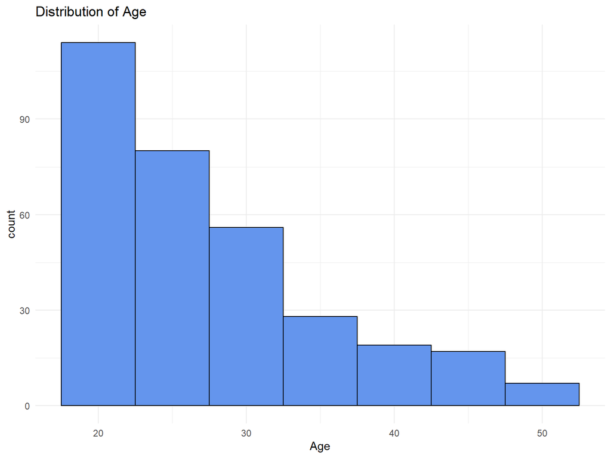

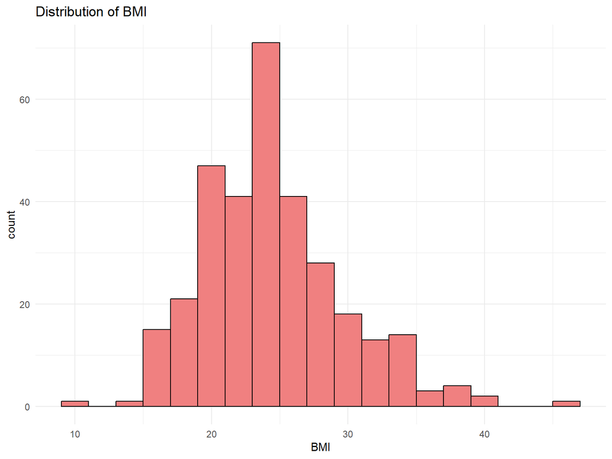

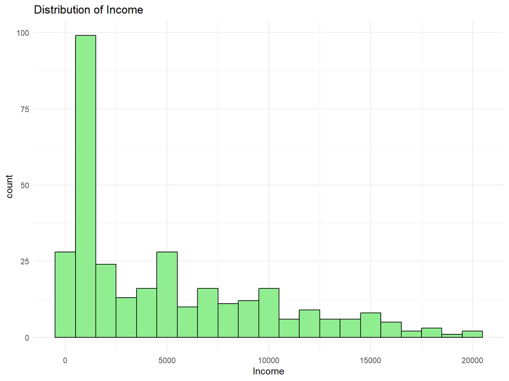

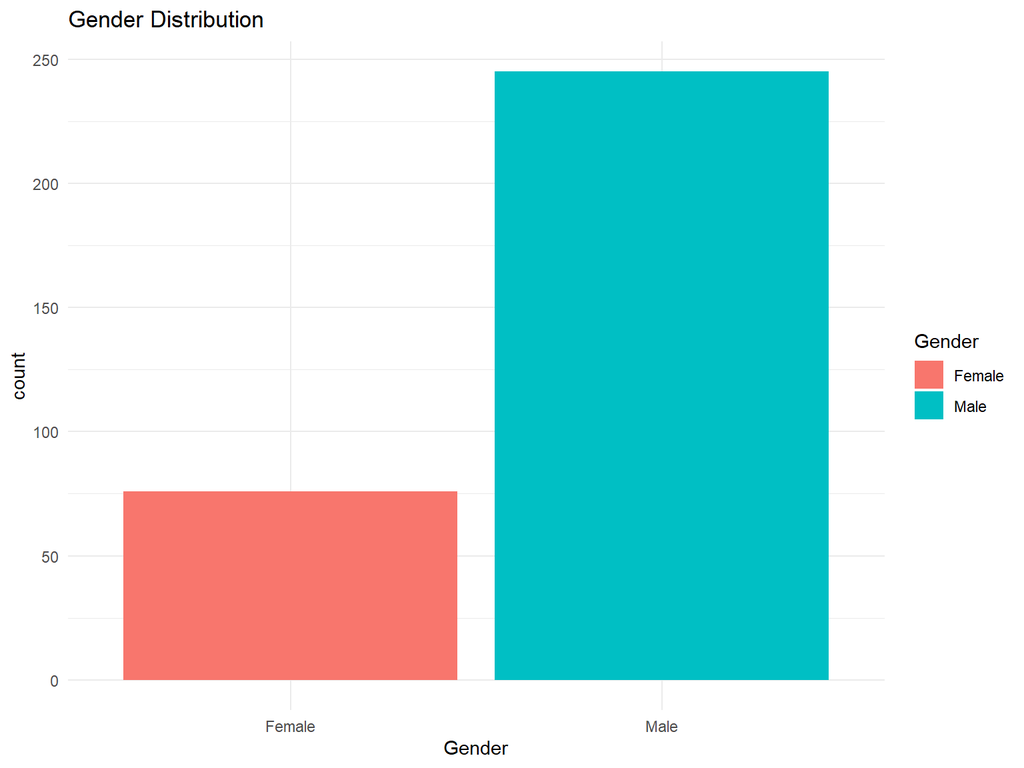

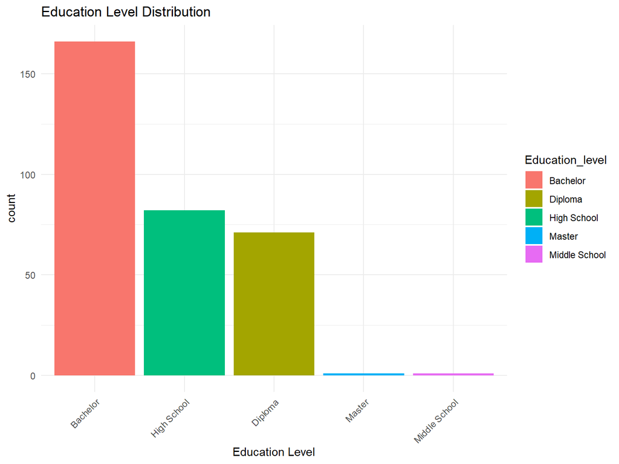

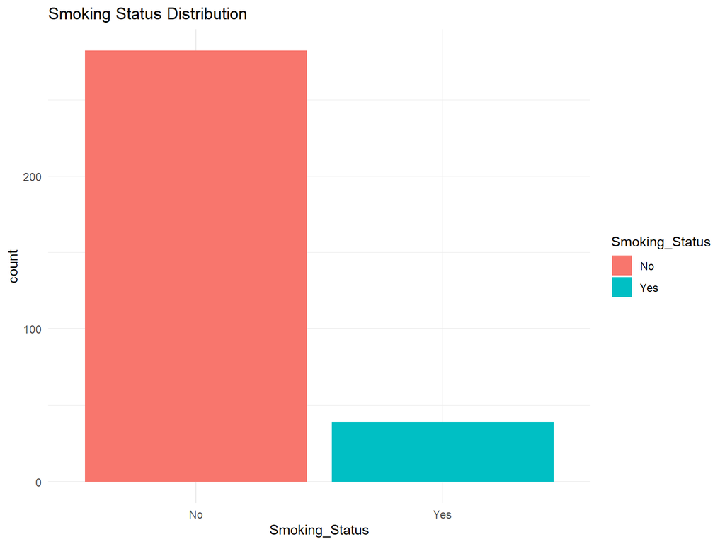

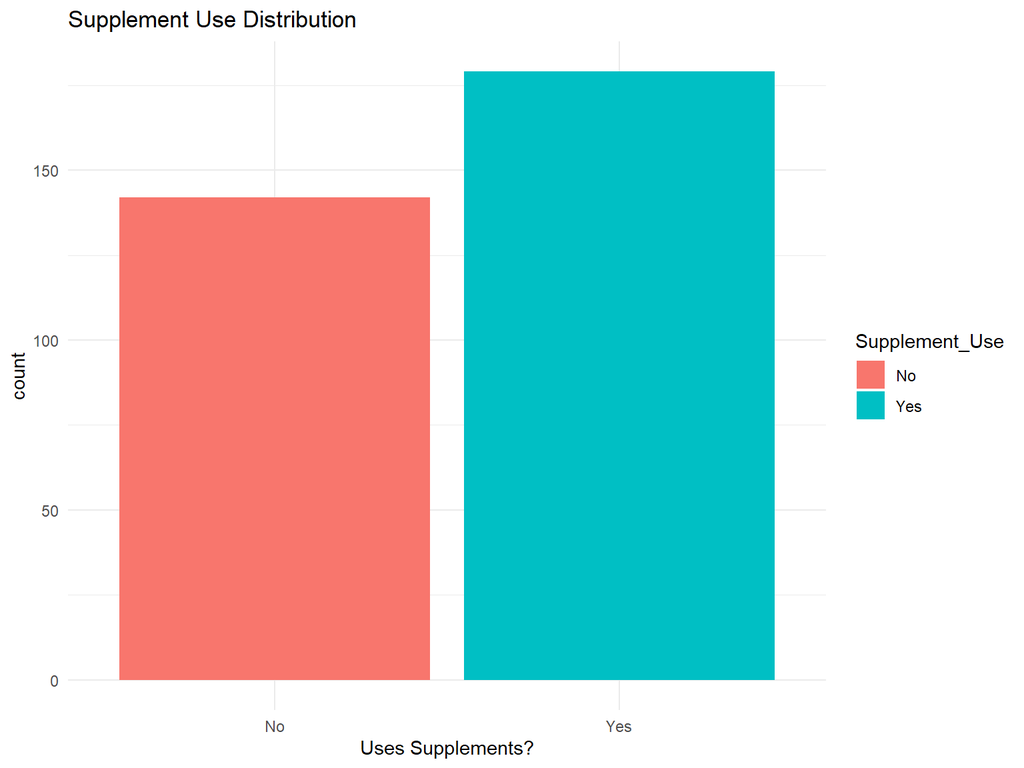

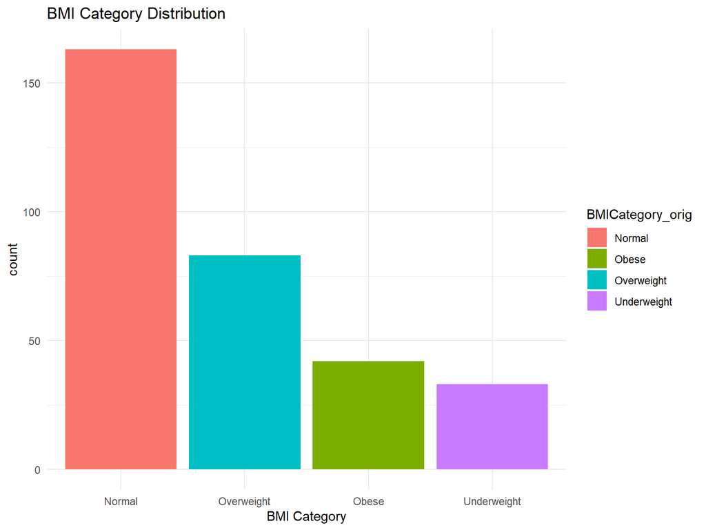

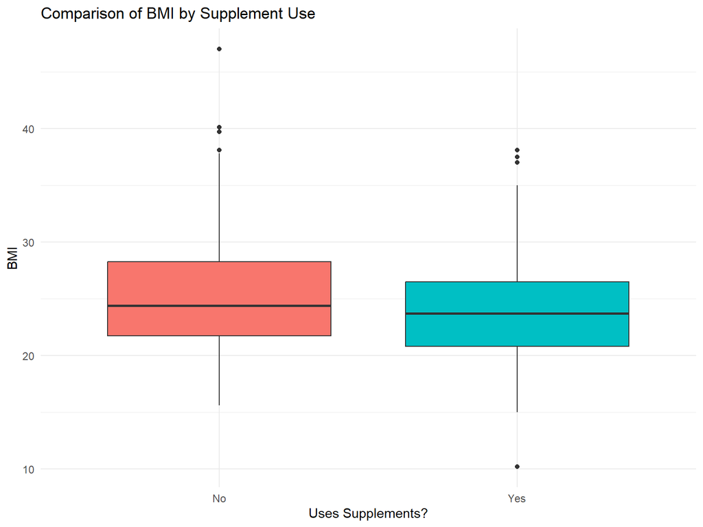

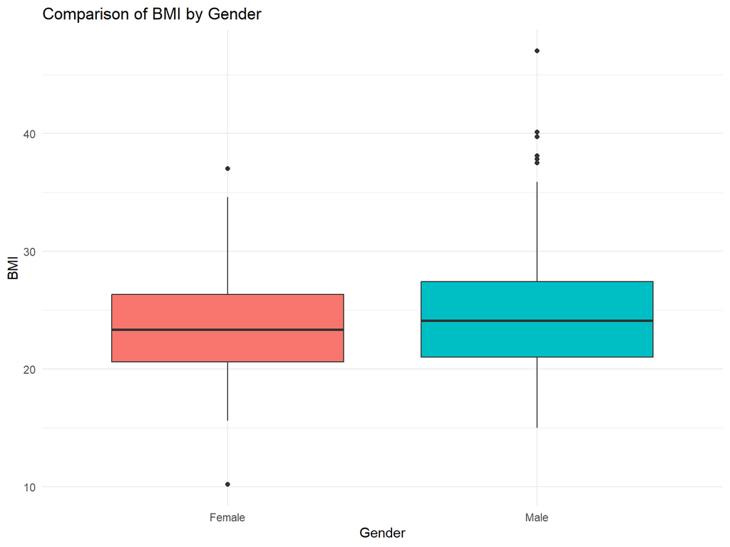

Figures 1-3 present histograms for the numeric variables Age, BMI, and Income, respectively, illustrating their distributions; Income, in particular, shows a strong right skew. Figures 4-8 display bar charts for the primary categorical variables: Gender distribution (Fig 4), Education levels (Fig 5), Smoking status (Fig 6), Supplement use prevalence (Fig 7), and the distribution across BMI categories (Fig 8). Finally, Figures 9 and 10 use box plots to compare BMI distributions between groups. Figure 9 visually supports the statistically significant difference in BMI observed between supplement users and non-users, while Figure 10 compares BMI distributions between males and females.

## 7. Conclusion

This analysis aimed to identify factors associated with dietary supplement use among participants surveyed for a graduation research project. The key finding across multiple analyses was a significant inverse relationship between Body Mass Index (BMI) and supplement use. Both bivariate analysis (t-test, p=0.040) and multivariate logistic regression (p=0.016, OR≈0.94) indicated that individuals with lower BMI had significantly higher odds of using supplements compared to those with higher BMI. Additionally, after data cleaning, a weak but statistically significant positive correlation was observed between Income and BMI (r=0.24, p<0.001). Other factors investigated, including age, gender, education level, and smoking status, were not found to be significant predictors of supplement use in the final logistic regression model when controlling for other variables.

In conclusion, within this sample, BMI appears to be the most prominent factor differentiating supplement users from non-users, with lower BMI individuals being more likely to use supplements.